# Applied Machine Learning - Dr. Keith Quille

# CA1 - Ryan Deering X00144631

```python
import pandas as pd
import matplotlib.pyplot as plt
import numpy as np
from sklearn import*
```

```python
filename = "x00144631.csv"
headerNames = [
"age",
"sex",
"cp",
"trestbps",
"chol",
"fbs",
"restecg",
"thalach",
"exang",
"oldpeak",
"slope",
"ca",
"thal",
"num"
]
dataog = pd.read_csv(filename, names=headerNames)
data = dataog[["thal", "exang", "fbs", "trestbps"]]
```

```python
data.head()
```

|  | thal | exang | fbs | trestbps |
| --- | --- | --- | --- | --- |
| 0 | 3 | 0 | 0 | 120 |
| 1 | 3 | 0 | 0 | 160 |
| 2 | 3 | 0 | 0 | 110 |
| 3 | 3 | 1 | 0 | 180 |
| 4 | 7 | 0 | 1 | 150 |

# Question 1

# Histogram

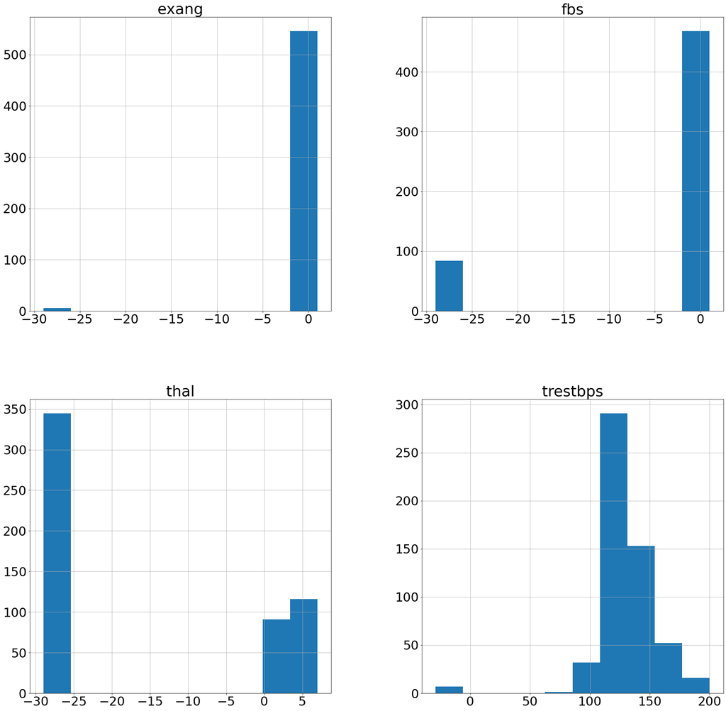

```python
plt.rc('font', size =30)
data.hist(figsize=(30,30))
plt.show()
```

Seeing some very interesting negative values already... Resting heart pressure at a negative? The only thing I'm positive about is that they're dead.

# Skew - Density Plot

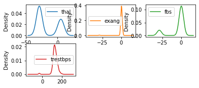

```python
plt.rc('font', size =10)
data.plot(kind='density',subplots=True, layout=(3,3), sharex=False)
plt.show()
```

# Data Descriptions

```python
print("Skek and description:\n--------------------------------")
print(data.skew())
print("Data Sescription:\n---------------------------------")
print(data.describe())
```

```
Skek and description:
--------------------------------
thal        0.532856
exang      -9.115321
fbs        -1.939191
trestbps   -2.531211
dtype: float64
Data Sescription:
---------------------------------
             thal       exang         fbs    trestbps
count  552.000000  552.000000  552.000000  552.000000
mean   -16.211957    0.032609   -4.333333  129.619565
std     16.564793    3.083065   10.463199   25.965009
min    -29.000000  -29.000000  -29.000000  -29.000000
25%    -29.000000    0.000000    0.000000  120.000000
50%    -29.000000    0.000000    0.000000  130.000000
75%      3.000000    1.000000    0.000000  140.000000
max      7.000000    1.000000    1.000000  200.000000
```

They all share a minimum negative of -29? Strange.

# Correlations for ALL data - pre-cleaned.

```python
print("Correlation Table")
corr = dataog.corr()
corr.style.background_gradient().set_precision(2)
```

```
Correlation Table
```

|  | age | sex | cp | trestbps | chol | fbs | restecg | thalach | exang | oldpeak | slope | ca | thal | num |
| --- | --- | --- | --- | --- | --- | --- | --- | --- | --- | --- | --- | --- | --- | --- |
| age | 1.00 | 0.04 | 0.20 | 0.13 | -0.22 | -0.10 | 0.13 | -0.40 | -0.07 | -0.03 | 0.32 | 0.18 | 0.23 | 0.25 |
| sex | 0.04 | 1.00 | 0.22 | -0.01 | -0.19 | -0.11 | -0.03 | -0.18 | 0.00 | -0.05 | 0.06 | -0.15 | -0.02 | 0.32 |
| cp | 0.20 | 0.22 | 1.00 | 0.01 | -0.19 | -0.17 | 0.04 | -0.30 | 0.07 | -0.00 | 0.33 | -0.02 | 0.15 | 0.50 |
| trestbps | 0.13 | -0.01 | 0.01 | 1.00 | 0.10 | 0.09 | 0.01 | 0.27 | 0.65 | 0.49 | 0.08 | 0.02 | 0.06 | 0.03 |
| chol | -0.22 | -0.19 | -0.19 | 0.10 | 1.00 | 0.48 | 0.02 | 0.22 | 0.07 | 0.17 | -0.15 | 0.20 | -0.13 | -0.27 |
| fbs | -0.10 | -0.11 | -0.17 | 0.09 | 0.48 | 1.00 | 0.07 | 0.09 | -0.04 | 0.08 | -0.13 | 0.15 | 0.03 | -0.27 |
| restecg | 0.13 | -0.03 | 0.04 | 0.01 | 0.02 | 0.07 | 1.00 | -0.04 | -0.03 | -0.02 | 0.06 | 0.12 | 0.10 | -0.03 |
| thalach | -0.40 | -0.18 | -0.30 | 0.27 | 0.22 | 0.09 | -0.04 | 1.00 | 0.50 | 0.38 | -0.10 | 0.18 | -0.03 | -0.33 |
| exang | -0.07 | 0.00 | 0.07 | 0.65 | 0.07 | -0.04 | -0.03 | 0.50 | 1.00 | 0.62 | 0.16 | 0.05 | 0.06 | 0.04 |
| oldpeak | -0.03 | -0.05 | -0.00 | 0.49 | 0.17 | 0.08 | -0.02 | 0.38 | 0.62 | 1.00 | 0.29 | 0.09 | -0.03 | -0.00 |
| slope | 0.32 | 0.06 | 0.33 | 0.08 | -0.15 | -0.13 | 0.06 | -0.10 | 0.16 | 0.29 | 1.00 | 0.38 | 0.36 | 0.45 |
| ca | 0.18 | -0.15 | -0.02 | 0.02 | 0.20 | 0.15 | 0.12 | 0.18 | 0.05 | 0.09 | 0.38 | 1.00 | 0.56 | -0.03 |
| thal | 0.23 | -0.02 | 0.15 | 0.06 | -0.13 | 0.03 | 0.10 | -0.03 | 0.06 | -0.03 | 0.36 | 0.56 | 1.00 | 0.20 |
| num | 0.25 | 0.32 | 0.50 | 0.03 | -0.27 | -0.27 | -0.03 | -0.33 | 0.04 | -0.00 | 0.45 | -0.03 | 0.20 | 1.00 |

# Correlations for the four attributes

```python
print("Correlation Table")
corr = data.corr()
corr.style.background_gradient().set_precision(2)
```

```
Correlation Table
```

|  | thal | exang | fbs | trestbps |
| --- | --- | --- | --- | --- |
| thal | 1.00 | 0.06 | 0.03 | 0.06 |
| exang | 0.06 | 1.00 | -0.04 | 0.65 |
| fbs | 0.03 | -0.04 | 1.00 | 0.09 |
| trestbps | 0.06 | 0.65 | 0.09 | 1.00 |

# Scatter Plot for all Attributes

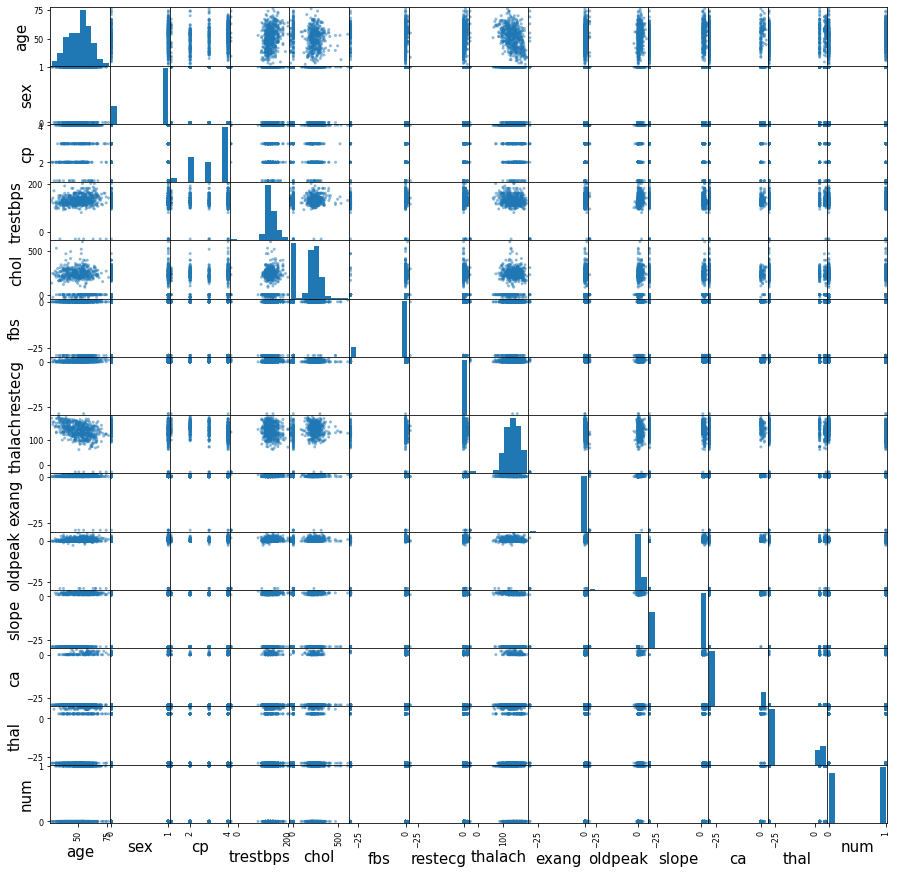

```python
plt.rc('font', size =15)
pd.plotting.scatter_matrix(dataog, figsize=(15,15))
plt.show()
```

# Scatter Plot for Selected Attributes

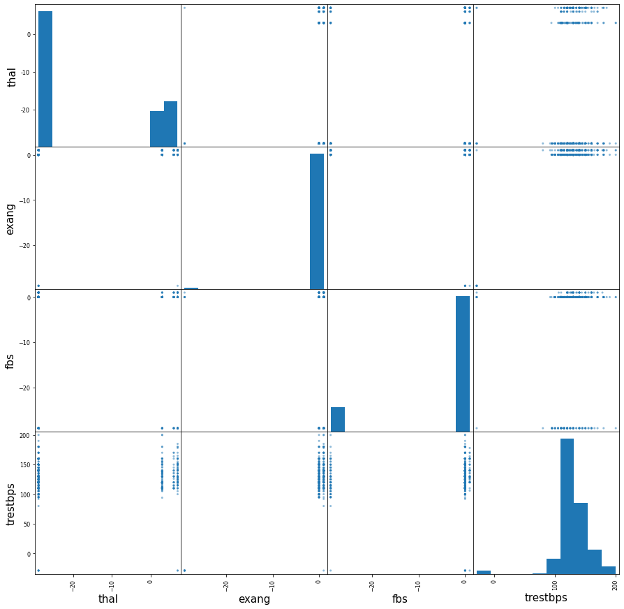

```python
plt.rc('font', size =15)
pd.plotting.scatter_matrix(data, figsize=(15,15))
plt.show()
```

# Class Counts

```python
class_counts1 = data.groupby('thal').size()
print(class_counts1)

class_counts2 = data.groupby('exang').size()
print(class_counts2)

class_counts3 = data.groupby('fbs').size()
print(class_counts3)
```

```
thal
-29    345
 3      91
 6      29
 7      87
dtype: int64
exang
-29      6
 0     354
 1     192
dtype: int64
fbs
-29     84
 0     424
 1      44
dtype: int64
```

# Head of data for selected attributes

```python
print(data.head(20))
```

```
    thal  exang  fbs  trestbps
0      3      0    0       120
1      3      0    0       160
2      3      0    0       110
3      3      1    0       180
4      7      0    1       150
5      7      0    0       140
6      7      0    0       110
7      7      1    0       142
8      7      1    0       128
9      7      1    0       144
10     3      0    0       130
11     3      1    0       150
12     3      0    0       120
13     7      1    0       120
14     3      0    0       130
15     7      1    1       178
16     3      0    0       112
17     7      0    0       120
18     3      0    0       105
19     3      1    0       138
```

# Question 2

For your specific four attributes, identify and discuss (giving reason based on graphical and statistical data from Q1 or additional) any missing data or outliers (if any) for each of your four attributes. Document what you plan to do with the missing values and/or outliers

# Function for attribute examination

```python
def plotAttribute(featureName):
    oneSTD = data[featureName].std()
    twoSTD = oneSTD * 2
    threeSTD = oneSTD * 3
    meanValue = data[featureName].mean()
    print("Attribute:", featureName.upper())
    print("Summary:")
    instances = data.shape[0]
    outsideTwo = ((data[featureName] < (meanValue - twoSTD)).sum() + (data[featureName] > (meanValue + twoSTD)).sum())
    outsideThree = ((data[featureName] < (meanValue - threeSTD)).sum() +(data[featureName] > (meanValue + threeSTD)).sum())

    print("N outside of two STD:\t", outsideTwo, "\t(", round((outsideTwo/instances) *100, 2),"%)")
    print("N outside of three STD:\t", outsideThree, "\t(", round((outsideThree/instances) * 100, 2),"%)")


    plt.axvline(x=(meanValue - oneSTD), label='One STD', c="g")
    plt.axvline(x=(meanValue + oneSTD), c="g")

    plt.axvline(x=(meanValue - twoSTD), label='Two STD', c="y")
    plt.axvline(x=(meanValue + twoSTD), c="y")

    plt.axvline(x=(meanValue - threeSTD), label='Three STD', c="r")
    plt.axvline(x=(meanValue + threeSTD), c="r")

    data[featureName].hist(figsize=(7,7))
    plt.legend()
    plt.show()
```

# Thal - values: 3, 6, 7 - Categorical

```
             thal
count  552.000000
mean   -16.211957
std     16.564793
min    -29.000000
25%    -29.000000
50%    -29.000000
75%      3.000000
max      7.000000

Attribute: THAL
Summary:
N outside of two STD:	 0 	( 0.0 %)
N outside of three STD:	 0 	( 0.0 %)
```

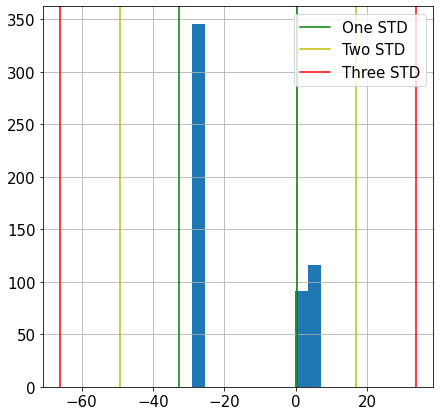

```python
print(data[["thal"]].describe())
print()
plotAttribute("thal")
```

The ranges of the data are 3, 6, 7. But we seem to have an almost overwhelming majority of bad data in this column. It is looking similar for the attributes. The best thing to do might be to remove the bad data entirely to preserve the quality of the legit, good data. However we could impute it also. But who knows. But we will come to that later.

```python
print("Amount not equal to 3,6 or 7")
print((data[["thal"]] == -29).sum())
missing = float((data[["thal"]] < 0).sum())
total = len(data)
percentageMissing = round(((missing / total)*100),2)
print("-------------------------------------------")
print("Missing percentage :", percentageMissing,"%")
```

```
Amount not equal to 3,6 or 7
thal    345
dtype: int64
-------------------------------------------
Missing percentage : 62.5 %
```

Yikes! That's quite a lot of data not in the usual ranges!

# Exang - Exercise induced angina. Range 1,0 - Class

```
            exang
count  552.000000
mean     0.032609
std      3.083065
min    -29.000000
25%      0.000000
50%      0.000000
75%      1.000000
max      1.000000

Attribute: EXANG
Summary:
N outside of two STD:	 6 	( 1.09 %)
N outside of three STD:	 6 	( 1.09 %)
```

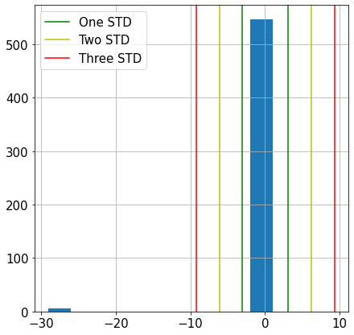

```python
print(data[["exang"]].describe())
print()
plotAttribute("exang")
```

We have six variables outside the range for angina. It's a class variable, so only 0 and 1 are the answers. Maybe just remove them, it won't affect the data that much.

```python
print("Amount not valid:")
missingCount = print((data[["exang"]] < 0).sum())
missing = float((data[["exang"]] < 0).sum())
total = len(data)
percentageMissing = round(((missing / total)*100),2)
print("-------------------------------------------")
print("Missing percentage :", percentageMissing,"%")
```

```
Amount not valid:
exang    6
dtype: int64
-------------------------------------------
Missing percentage : 1.09 %
```

# Fbs - Fasting blood sugar > 120 mg/dl (1 = true; 0 = false) - Class

```
              fbs
count  552.000000
mean    -4.333333
std     10.463199
min    -29.000000
25%      0.000000
50%      0.000000
75%      0.000000
max      1.000000

Attribute: FBS
Summary:
N outside of two STD:	 84 	( 15.22 %)
N outside of three STD:	 0 	( 0.0 %)
```

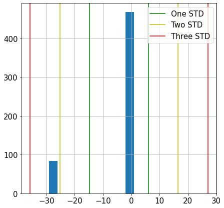

```python
print(data[["fbs"]].describe())
print()
plotAttribute("fbs")
```

84 invalid variables. Pretty straight forward.

```python
print("Amount not valid:")
missingCount = print((data[["fbs"]] < 0).sum())
missing = float((data[["fbs"]] < 0).sum())
total = len(data)
percentageMissing = round(((missing / total)*100),2)
print("-------------------------------------------")
print("Missing percentage :", percentageMissing,"%")
```

```
Amount not valid:
fbs    84
dtype: int64
-------------------------------------------
Missing percentage : 15.22 %
```

Since it's greater than 5%, might be better to impute.

# trestbps - Resting blood pressure - MUST be positive. - Continous

```
         trestbps
count  552.000000
mean   129.619565
std     25.965009
min    -29.000000
25%    120.000000
50%    130.000000
75%    140.000000
max    200.000000

Attribute: TRESTBPS
Summary:
N outside of two STD:	 12 	( 2.17 %)
N outside of three STD:	 7 	( 1.27 %)
```

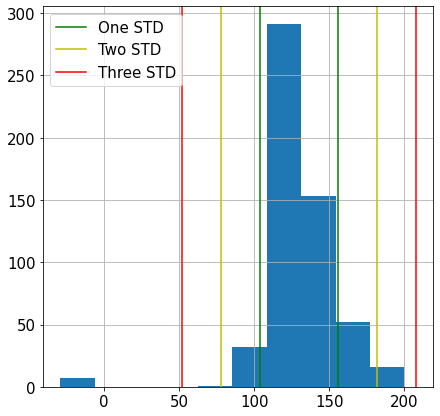

```python
print(data[["trestbps"]].describe())
print()
plotAttribute("trestbps")
```

```python
print("Amount not valid:")
missingCount = print((data[["trestbps"]] < 0).sum())
missing = float((data[["trestbps"]] < 0).sum())
total = len(data)
percentageMissing = round(((missing / total)*100),2)
print("-------------------------------------------")
print("Missing percentage :", percentageMissing,"%")
```

```
Amount not valid:
trestbps    7
dtype: int64
-------------------------------------------
Missing percentage : 1.27 %
```

# Question 3

Mark and clean the data your choices must be based on your documented answer to question 2. Create a CSV file of this clean data called: yourXnumberQ3.csv

For thal, exang and fbs, we're looking for -29 as it is the ONLY invalid value that is present in those attributes.

For trestbps, we're looking for negative values.

```python
# Thal
dataog[["thal"]] = dataog[["thal"]].mask(dataog[["thal"]] == -29, np.NaN)
print("\nNaN Using == -29: ", float(dataog[["thal"]].isnull().sum()))

# Exang
dataog[["exang"]] = dataog[["exang"]].mask(dataog[["exang"]] == -29, np.NaN)
print("\nNaN Using == -29: ", float(dataog[["exang"]].isnull().sum()))

# Fbs
dataog[["fbs"]] = dataog[["fbs"]].mask(dataog[["fbs"]] == -29, np.NaN)
print("\nNaN Using == -29: ", float(dataog[["fbs"]].isnull().sum()))

# Trestbps
dataog[["trestbps"]] = dataog[["trestbps"]].mask(dataog[["trestbps"]] < 0, np.NaN)
print("\nNaN Using < 0: ", float(dataog[["trestbps"]].isnull().sum()))
```

```
NaN Using == -29:  345.0

NaN Using == -29:  6.0

NaN Using == -29:  84.0

NaN Using < 0:  7.0
```

For exang and trestbps, we are going to remove the rows that have invalid data. They only have very small amount of outliers, both hovering around 1% respectively, so it won't affect the dataset too much.

```python
 # print shape first
print(dataog.shape)
# drop rows with missing values
dataog = dataog[dataog['exang'].notna()]
dataog = dataog[dataog['trestbps'].notna()]
# summarize the number of rows and columns in the dataset
print(dataog.shape)
```

```
(552, 14)
(545, 14)
```

For the rest, we are going to impute the values. Why? Well, there is much greater amounts of data. If we were to delete 345 rows of data, of which the data now has 545, that'd be a serious amount of damage done to the dataset. The overall quality would be much higher, but I am not sure if it would be suitable for a machine learning model. I am also worried about skewing the data.

```python
print(dataog['thal'].mode())
print(dataog['fbs'].mode())
```

```
0    3.0
dtype: float64
0    0.0
dtype: float64
```

As we can see from here, the most common value for thal is 3. For fbs, it is 0. We will impute the missing values with these. However, I have my doubts whether this is the right solution. I am not sure if there is a right solution here, but for the purposes of this CA, this is what I'll do.

I will be giving 345 people more the same '3' value for the thal column, while it is clear from the graphs that people do seem to have the '3' value the most, the data is going to be heavily skewed.

But it means the rest of their data is usable. But one has to question whether it'd be better to remove it entirely or not.

```python
#Imputation code
dataog['thal'].fillna(3, inplace=True)
dataog['fbs'].fillna(0, inplace=True)
```

```python
def plotAttribute2(featureName):
    oneSTD = dataog[featureName].std()
    twoSTD = oneSTD * 2
    threeSTD = oneSTD * 3
    meanValue = dataog[featureName].mean()
    print("Attribute:", featureName.upper())
    print("Summary:")
    instances = dataog.shape[0]
    outsideTwo = ((dataog[featureName] < (meanValue - twoSTD)).sum() + (dataog[featureName] > (meanValue + twoSTD)).sum())
    outsideThree = ((dataog[featureName] < (meanValue - threeSTD)).sum() +(dataog[featureName] > (meanValue + threeSTD)).sum())

    print("N outside of two STD:\t", outsideTwo, "\t(", round((outsideTwo/instances) *100, 2),"%)")
    print("N outside of three STD:\t", outsideThree, "\t(", round((outsideThree/instances) * 100, 2),"%)")


    plt.axvline(x=(meanValue - oneSTD), label='One STD', c="g")
    plt.axvline(x=(meanValue + oneSTD), c="g")

    plt.axvline(x=(meanValue - twoSTD), label='Two STD', c="y")
    plt.axvline(x=(meanValue + twoSTD), c="y")

    plt.axvline(x=(meanValue - threeSTD), label='Three STD', c="r")
    plt.axvline(x=(meanValue + threeSTD), c="r")

    dataog[featureName].hist(figsize=(7,7))
    plt.legend()
    plt.show()
```

Verifying imputation worked.

```
Attribute: THAL
Summary:
N outside of two STD:	 85 	( 15.6 %)
N outside of three STD:	 0 	( 0.0 %)
```

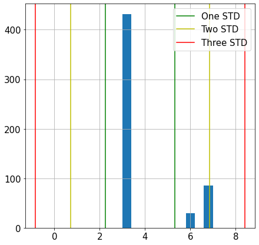

```
Attribute: FBS
Summary:
N outside of two STD:	 43 	( 7.89 %)
N outside of three STD:	 43 	( 7.89 %)
```

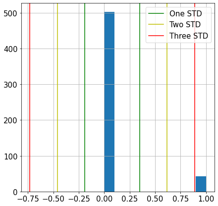

```python
plotAttribute2('thal')
plotAttribute2('fbs')
```

It did!

```python
dataog.to_csv("x00144631Q3.csv",header=False)
```

# Question 4

Visualize the data again with your assigned four attributes cleaned, identify one set of attributes that are multicollinear within your four attributes and explain why. Then include one set of attributes that are multicollinear using all the attributes excluding the class value (note as you are given a unique dataset, the pearson values may be low, you should still select the hight correlated attributes even if the values are low).

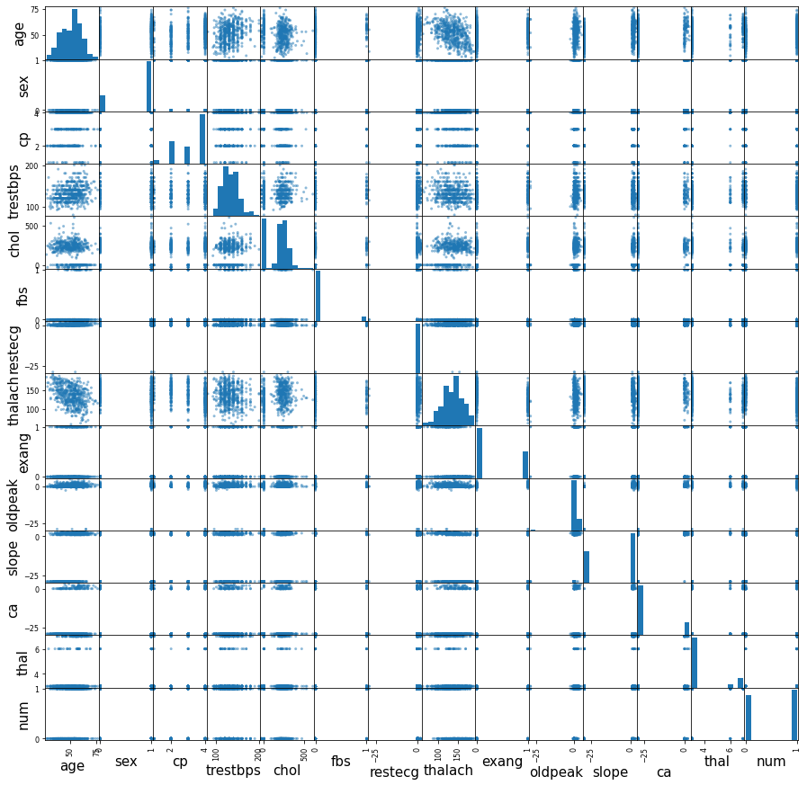

```python
plt.rc('font', size =15)
pd.plotting.scatter_matrix(dataog, figsize=(15,15))
plt.show()
```

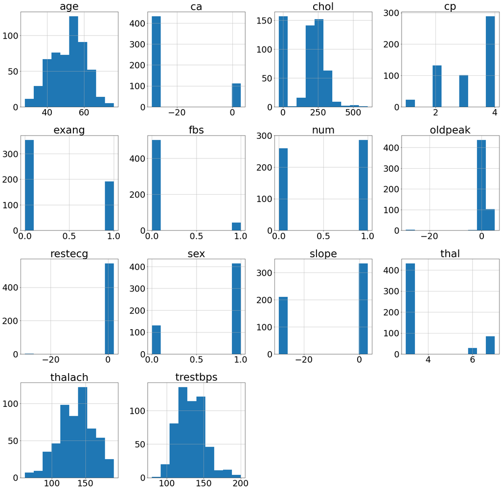

```python
plt.rc('font', size =30)
dataog.hist(figsize=(30,30))
plt.show()
```

```python
corr = dataog.corr()
corr.style.background_gradient().set_precision(2)
```

|  | age | sex | cp | trestbps | chol | fbs | restecg | thalach | exang | oldpeak | slope | ca | thal | num |
| --- | --- | --- | --- | --- | --- | --- | --- | --- | --- | --- | --- | --- | --- | --- |
| age | 1.00 | 0.04 | 0.20 | 0.25 | -0.21 | 0.19 | 0.12 | -0.42 | 0.18 | 0.04 | 0.34 | 0.19 | 0.20 | 0.26 |
| sex | 0.04 | 1.00 | 0.22 | 0.02 | -0.18 | 0.04 | -0.03 | -0.20 | 0.14 | -0.00 | 0.07 | -0.15 | 0.16 | 0.32 |
| cp | 0.20 | 0.22 | 1.00 | 0.03 | -0.18 | 0.04 | 0.04 | -0.37 | 0.45 | 0.04 | 0.34 | -0.02 | 0.22 | 0.50 |
| trestbps | 0.25 | 0.02 | 0.03 | 1.00 | 0.05 | 0.12 | 0.04 | -0.14 | 0.16 | 0.03 | 0.01 | -0.03 | 0.08 | 0.08 |
| chol | -0.21 | -0.18 | -0.18 | 0.05 | 1.00 | 0.06 | 0.02 | 0.22 | -0.02 | 0.13 | -0.17 | 0.20 | -0.19 | -0.27 |
| fbs | 0.19 | 0.04 | 0.04 | 0.12 | 0.06 | 1.00 | 0.05 | -0.05 | 0.07 | -0.02 | 0.05 | 0.04 | 0.08 | 0.13 |
| restecg | 0.12 | -0.03 | 0.04 | 0.04 | 0.02 | 0.05 | 1.00 | -0.02 | 0.06 | 0.01 | 0.06 | 0.13 | 0.06 | -0.04 |
| thalach | -0.42 | -0.20 | -0.37 | -0.14 | 0.22 | -0.05 | -0.02 | 1.00 | -0.36 | 0.07 | -0.18 | 0.18 | -0.18 | -0.38 |
| exang | 0.18 | 0.14 | 0.45 | 0.16 | -0.02 | 0.07 | 0.06 | -0.36 | 1.00 | 0.14 | 0.41 | -0.02 | 0.20 | 0.48 |
| oldpeak | 0.04 | -0.00 | 0.04 | 0.03 | 0.13 | -0.02 | 0.01 | 0.07 | 0.14 | 1.00 | 0.29 | 0.08 | -0.01 | 0.07 |
| slope | 0.34 | 0.07 | 0.34 | 0.01 | -0.17 | 0.05 | 0.06 | -0.18 | 0.41 | 0.29 | 1.00 | 0.38 | 0.22 | 0.46 |
| ca | 0.19 | -0.15 | -0.02 | -0.03 | 0.20 | 0.04 | 0.13 | 0.18 | -0.02 | 0.08 | 0.38 | 1.00 | 0.20 | -0.03 |
| thal | 0.20 | 0.16 | 0.22 | 0.08 | -0.19 | 0.08 | 0.06 | -0.18 | 0.20 | -0.01 | 0.22 | 0.20 | 1.00 | 0.31 |
| num | 0.26 | 0.32 | 0.50 | 0.08 | -0.27 | 0.13 | -0.04 | -0.38 | 0.48 | 0.07 | 0.46 | -0.03 | 0.31 | 1.00 |

```python
print("Correlation Table")
corr = dataog[["thal", "exang", "fbs", "trestbps"]].corr()
corr.style.background_gradient().set_precision(2)
```

```
Correlation Table
```

|  | thal | exang | fbs | trestbps |
| --- | --- | --- | --- | --- |
| thal | 1.00 | 0.20 | 0.08 | 0.08 |
| exang | 0.20 | 1.00 | 0.07 | 0.16 |
| fbs | 0.08 | 0.07 | 1.00 | 0.12 |
| trestbps | 0.08 | 0.16 | 0.12 | 1.00 |

Out of the whole dataset: Num and cp (Heart disease status and chest pain) have a medium correlation of 0.50. Why? I can only hypothesise that the worse your heart disease is, the more likely you are to have chest pain. Also, num and exang share a correlation 0.48, which is medium. Which I can only assume the worse your heart disease is, the more likely you are to suffer with angina!

# Question 5

Normalize your data, as it may be used in specific machine learning algorithms, Create a CSV file of this normalized clean data called: Q5.csv

```python
# Convert to array
array = dataog.values
# get seperated input and classifies, using a deep copy of a list
X = array[:,0:13]
Y = array[:,13]
scaler = preprocessing.Normalizer().fit(X)
normalizedX = scaler.transform(X)
#Convert back to Pandas
normX = pd.DataFrame(normalizedX)
Y = pd.DataFrame(Y)
# Concatinating the dataframes back together
outData = pd.concat([normX, Y], axis=1, sort=False)
# Saving the data
outData.to_csv("x00144631Q5.csv",header=False, index=False)
```

# Question 6

Use any two techniques to select the top three attributes for a prediction model. Document the top three attributes for each technique and finally determine the best attributes if they appear in both techniques. (note: not all techniques may work and given you are randomly assigned attributes to address, it is possible that no attribute appears in both techniques – report the findings in any case)

```python
array = dataog.values
# get seperated input and classifies, using a deep copy of a list
X = array[:,0:13]
Y = array[:,13]
model = linear_model.LogisticRegression()
rfe = feature_selection.RFE(model, 3)
fit = rfe.fit(X, Y)
print("Num Features: %d" % fit.n_features_)
print("\n{0:<20}".format("Attribute"), "{0:<20}".format("Select?"), "{0:<20}".format("Rank"))
print("-----------------------------------------------------------------------------------")
for index, result in enumerate(list(fit.ranking_)):
    print("{0:<20}".format(headerNames[index]), "{0:<20}".format(fit.support_[index]), "{0:<20}".format(result))
```

```
Num Features: 3

Attribute            Select?              Rank
-----------------------------------------------------------------------------------
age                  0                    9
sex                  1                    1
cp                   0                    2
trestbps             0                    11
chol                 0                    10
fbs                  1                    1
restecg              0                    4
thalach              0                    7
exang                1                    1
oldpeak              0                    8
slope                0                    5
ca                   0                    6
thal                 0                    3
```

[output not shown]

# Regression

```python
array = dataog.values
# get seperated input and classifies, using a deep copy of a list
X = array[:,0:13]
Y = array[:,13]
test = feature_selection.SelectKBest(score_func=feature_selection.f_regression,k=4)
fit = test.fit(X, Y)
print()
# have to manually display as no function to do so available
for index, result in enumerate(fit.scores_):
    print("{0:10}".format(headerNames[index]),"{0:10}".format(round(result,2)))
```

```
age             39.61
sex             60.22
cp             179.75
trestbps         3.43
chol            41.29
fbs              9.13
restecg          0.75
thalach         90.18
exang           158.8
oldpeak          2.75
slope          149.03
ca                0.4
thal            57.04
```

RFE Attributes for Selection: Rank 1: Sex, FBS, Exang Regression Attributes for Selection: Cp, Exang, Slope

Common attributes: Exang

Conclusion: Exang must be the best attribute for selection, if we are going to be using a prediction model. However, I only used two techniques so there may be more.